# Storm Event Data (1996 to 2011) Analysis: Health and Economic Impact in USA

Suparna Sen

25 March 2016

Storms and other severe weather events can cause both public health and economic problems for communities and municipalities. Many severe events can result in fatalities, injuries, and property damage, and preventing such outcomes to the extent possible is a key concern. This project involves exploring the U.S. National Oceanic and Atmospheric Administration’s (NOAA) storm database. This database tracks characteristics of major storms and weather events in the United States, including when and where they occur, as well as estimates of any fatalities, injuries, and property damage.

# I. Synopsis

The Storm Events Database contains the records used to create the official NOAA Storm Data publication.This database tracks characteristics of major storms and weather events in the United States, including when and where they occur, as well as estimates of any fatalities, injuries, and property damage. The database currently contains data from January 1950 to December 2015, as entered by NOAA’s National Weather Service (NWS).

The purpose of this analysis is to reveal the major types of storm events and their impact on both: * the human population (deaths and injuries), and * the economic impact (property and crop damage.)

# II. Data Processing

- Package used: R Statistical Package
- The analysis was performed on [Storm Events Database](http://www.ncdc.noaa.gov/stormevents/ftp.jsp), provided by [National Climatic Data Center](http://www.ncdc.noaa.gov/).
- Data Source : [comma-separated-value Data File](https://d396qusza40orc.cloudfront.net/repdata%2Fdata%2FStormData.csv.bz2)
- Documentations on the Data:
  - [National Weather Service Storm Data Documentation](https://d396qusza40orc.cloudfront.net/repdata%2Fpeer2_doc%2Fpd01016005curr.pdf)
  - [Storm Events Layout](http://ire.org/media/uploads/files/datalibrary/samplefiles/Storm%20Events/layout08.doc)
- A researcher named Mauricio Linhares has developed a substitiution table to eliminate the various misspellings and duplicate entries in the EVNTYPE field.
  - With the help of [replacements.csv](http://mauricio.github.io/2014/12/23/getting-and-clearning-data.html), a csv file from researcher Maricio Lihnares, that contains the mappings from the original to the canonical event type. With help of this the event categories can be reduced to a more manageable numbers.

## II-a. Data Loading and Extracting

```r
setwd("E:/COURSERA/REPRODUCIBLE RESEARCH/assignment-final-week-4/repdata-data-StormData")
if (!file.exists("repdata-data-StormData.csv")) {
  download.file("https://d396qusza40orc.cloudfront.net/repdata%2Fdata%2FStormData.csv.bz2",
                file="repdata-data-StormData.csv.bz2")
  dateDownloaded=date()

  bunzip2(file="repdata-data-StormData.csv.bz2",destname="repdata-data-StormData.csv")
  unlink("repdata-data-StormData.csv.bz2")
}

dataset<-read.csv("repdata-data-StormData.csv",header=TRUE,sep = ",", stringsAsFactors = FALSE)
#Variable names in the dataset
names(dataset)
```

```
##  [1] "STATE__"    "BGN_DATE"   "BGN_TIME"   "TIME_ZONE"  "COUNTY"
##  [6] "COUNTYNAME" "STATE"      "EVTYPE"     "BGN_RANGE"  "BGN_AZI"
## [11] "BGN_LOCATI" "END_DATE"   "END_TIME"   "COUNTY_END" "COUNTYENDN"
## [16] "END_RANGE"  "END_AZI"    "END_LOCATI" "LENGTH"     "WIDTH"
## [21] "F"          "MAG"        "FATALITIES" "INJURIES"   "PROPDMG"
## [26] "PROPDMGEXP" "CROPDMG"    "CROPDMGEXP" "WFO"        "STATEOFFIC"
## [31] "ZONENAMES"  "LATITUDE"   "LONGITUDE"  "LATITUDE_E" "LONGITUDE_"
## [36] "REMARKS"    "REFNUM"
```

## II-b. Data Cleaning and Exploratory Analysis

```r
# Dimensions - Records and Variables
dim(dataset)
```

```
## [1] 902297     37
```

```r
# Number of NA records
sum(is.na(dataset))
```

```
## [1] 1745947
```

```r
# Display the Structure
str(dataset)
```

```
## 'data.frame':    902297 obs. of  37 variables:
##  $ STATE__   : num  1 1 1 1 1 1 1 1 1 1 ...
##  $ BGN_DATE  : chr  "4/18/1950 0:00:00" "4/18/1950 0:00:00" "2/20/1951 0:00:00" "6/8/1951 0:00:00" ...
##  $ BGN_TIME  : chr  "0130" "0145" "1600" "0900" ...
##  $ TIME_ZONE : chr  "CST" "CST" "CST" "CST" ...
##  $ COUNTY    : num  97 3 57 89 43 77 9 123 125 57 ...
##  $ COUNTYNAME: chr  "MOBILE" "BALDWIN" "FAYETTE" "MADISON" ...
##  $ STATE     : chr  "AL" "AL" "AL" "AL" ...
##  $ EVTYPE    : chr  "TORNADO" "TORNADO" "TORNADO" "TORNADO" ...
##  $ BGN_RANGE : num  0 0 0 0 0 0 0 0 0 0 ...
##  $ BGN_AZI   : chr  "" "" "" "" ...
##  $ BGN_LOCATI: chr  "" "" "" "" ...
##  $ END_DATE  : chr  "" "" "" "" ...
##  $ END_TIME  : chr  "" "" "" "" ...
##  $ COUNTY_END: num  0 0 0 0 0 0 0 0 0 0 ...
```

[output cut: 23 more lines]

```r
#Number of unique events
events = unique(dataset$EVTYPE)
length(events)
```

```
## [1] 985
```

```r
#The diferent variable heads in the data set
names(dataset)
```

```
##  [1] "STATE__"    "BGN_DATE"   "BGN_TIME"   "TIME_ZONE"  "COUNTY"
##  [6] "COUNTYNAME" "STATE"      "EVTYPE"     "BGN_RANGE"  "BGN_AZI"
## [11] "BGN_LOCATI" "END_DATE"   "END_TIME"   "COUNTY_END" "COUNTYENDN"
## [16] "END_RANGE"  "END_AZI"    "END_LOCATI" "LENGTH"     "WIDTH"
## [21] "F"          "MAG"        "FATALITIES" "INJURIES"   "PROPDMG"
## [26] "PROPDMGEXP" "CROPDMG"    "CROPDMGEXP" "WFO"        "STATEOFFIC"
## [31] "ZONENAMES"  "LATITUDE"   "LONGITUDE"  "LATITUDE_E" "LONGITUDE_"
## [36] "REMARKS"    "REFNUM"
```

## II-c. Data of Interest for this Analysis

**Variables**

**Window frame of data to be used:** events that have happened since 1996,

```r
# Subset of interest
stormDataset <- dataset[, c("BGN_DATE", "COUNTY", "COUNTYNAME", "STATE", "END_DATE","EVTYPE",
                            "FATALITIES","INJURIES","PROPDMG","PROPDMGEXP","CROPDMG","CROPDMGEXP")]
dim(stormDataset)
```

```
## [1] 902297     12
```

- Scanned through the data using unique(stormDataset$EVTYPE) and found typo errors and many duplications in the event types (ENVTYP)

```r
#Converting all Event types to upper case and Triming of data - remove extraneous spaces from the beginning or the end of the event names
stormDataset$EVTYPE <- toupper(gsub("^\\s+|\\s+$", "", stormDataset$EVTYPE))

#Discarding data element as "SUMMARY" as event type
stormDataset=stormDataset[!grepl("SUMMARY", stormDataset$EVTYPE), ]
dim(stormDataset)
```

```
## [1] 902221     12
```

```r
#Filtering out NON-AVAILABLE data for "FATALITIES","INJURIES","PROPDMG","PROPDMGEXP","CROPDMG","CROPDMGEXP" to reduce the set
stormDataset = stormDataset[stormDataset$FATALITIES>0 |
                              stormDataset$INJURIES > 0 |
                              stormDataset$PROPDMG > 0 |
                              stormDataset$PROPDMGEXP>0 |
                              stormDataset$CROPDMGEXP>0 |
                              stormDataset$CROPDMG > 0, ]
#new dimensions are
dim(stormDataset)
```

```
## [1] 447962     12
```

## II-d. Downloading [replacements.csv](http://mauricio.github.io/2014/12/23/getting-and-clearning-data.html), a csv file from researcher Maricio Lihnares, that contains the mappings from the original to the canonical event type.

```r
replacements <- read.csv("replacements.csv", stringsAsFactors=FALSE)
eventFor <- function( evtype ) {
  replacements[replacements$event == evtype,]$actual
}
stormDataset$CLNEVTYPE <- sapply(stormDataset$EVTYPE, eventFor)

#Count of unique cleaned event types
length(unique(stormDataset$CLNEVTYPE))
```

```
## [1] 126
```

```r
#Selecting data within the window - since 1996 and creating a new dataframe
stormDataset$BGN_DATE=as.Date(stormDataset$BGN_DATE, format = "%m/%d/%Y")
stormData1996 = stormDataset[(stormDataset$BGN_DATE >= "1996-01-01"), ]
dim(stormData1996)
```

```
## [1] 385819     13
```

```r
# Unique event count in the new dataframe
events = unique(stormData1996$EVTYPE)
length(events)
```

```
## [1] 185
```

```r
#Summary Information: of the new data frame
summary(stormData1996)
```

```
##     BGN_DATE              COUNTY        COUNTYNAME
##  Min.   :1996-01-01   Min.   :  1.00   Length:385819
##  1st Qu.:2004-05-21   1st Qu.: 29.00   Class :character
##  Median :2008-05-21   Median : 73.00   Mode  :character
##  Mean   :2006-11-14   Mean   : 99.22
##  3rd Qu.:2010-05-17   3rd Qu.:127.00
##  Max.   :2011-11-30   Max.   :873.00
##     STATE             END_DATE            EVTYPE
##  Length:385819      Length:385819      Length:385819
##  Class :character   Class :character   Class :character
##  Mode  :character   Mode  :character   Mode  :character
##
##
##
##    FATALITIES           INJURIES            PROPDMG
##  Min.   :  0.00000   Min.   :   0.0000   Min.   :   0.0
##  1st Qu.:  0.00000   1st Qu.:   0.0000   1st Qu.:   0.0
##  Median :  0.00000   Median :   0.0000   Median :   0.0
##  Mean   :  0.02263   Mean   :   0.1503   Mean   :  19.8
##  3rd Qu.:  0.00000   3rd Qu.:   0.0000   3rd Qu.:   8.0
##  Max.   :158.00000   Max.   :1150.0000   Max.   :5000.0
##   PROPDMGEXP           CROPDMG         CROPDMGEXP
##  Length:385819      Min.   :  0.000   Length:385819
##  Class :character   1st Qu.:  0.000   Class :character
##  Mode  :character   Median :  0.000   Mode  :character
##                     Mean   :  3.115
##                     3rd Qu.:  0.000
##                     Max.   :990.000
##   CLNEVTYPE
##  Length:385819
##  Class :character
##  Mode  :character
##
##
##
```

## II-e. Refactor PROPDMG, CROPDMG, PROPDMGEXP & CROPDMGEXP to absolute damage values

- The multipliers PROPDMGEXP and CROPDMGEXP has values K (for thousands), M (for millions) and B (for billions) of USD

```r
#Converting to uppercase
stormData1996$PROPDMGEXP <- toupper(stormData1996$PROPDMGEXP)
stormData1996$CROPDMGEXP <- toupper(stormData1996$CROPDMGEXP)
#Having a look at the unique values of PRODMGEXP
unique(stormData1996$PROPDMGEXP)
```

```
## [1] "K" ""  "M" "B" "0"
```

```r
#Having a look at the unique values of CROPDMGEXP
unique(stormData1996$CROPDMGEXP)
```

```
## [1] "K" ""  "M" "B"
```

- Function to convert symbol to a power of 10 (for use with PROPDMGEXP & CROPDMGEXP)

```r
toTenPower <- function(x){
  if(is.numeric(x)) {
    x <- x
  }
  else if(grepl("h", x, ignore.case=TRUE)) {
    x <- 2
  }
  else if(grepl("k", x, ignore.case=TRUE)) {
    x <- 3
  }
  else if(grepl("m", x, ignore.case=TRUE)) {
    x <- 6
  }
  else if(grepl("b", x, ignore.case=TRUE)) {
    x <- 9
  }
  else if(x == "" || x == " "){
    x <- 0
  }
  else{
    x <- NA
  }
  x
}
```

- Function to take two parameters num and exp and convert it to one absolute value. non integers become 0

```r
calculateAmount <- function(num, exp){
  pow <- toTenPower(exp)
  if(is.numeric(num)){
    num <- num * (10 ^ pow)
  }

  if(!is.numeric(num)){
    num <- 0
  }

  num
}

#creating 2 new fields for calculated propDamage & cropDamage and add them to one damageTotal field

stormData1996$PROPERTY_DAMAGE <- mapply(calculateAmount,
                                        stormData1996$PROPDMG, stormData1996$PROPDMGEXP)
stormData1996$CROP_DAMAGE <- mapply(calculateAmount,
                                    stormData1996$CROPDMG, stormData1996$CROPDMGEXP)
stormData1996$TOTAL_DAMAGE<-stormData1996$PROPERTY_DAMAGE+stormData1996$CROP_DAMAGE
```

# III. RESULTS

- DATA ANALYSIS & RESULTS (Top 10 most harmful events)

## III-A. Across the United States, which types of events (as indicated in the EVTYPE variable) are most harmful with respect to population health?

- Aggregating event types by total fatalities

```r
fatalities <- aggregate(stormData1996$FATALITIES ~ stormData1996$EVTYPE, FUN=sum)
dim(fatalities)
```

```
## [1] 185   2
```

```r
names(fatalities)
```

```
## [1] "stormData1996$EVTYPE"     "stormData1996$FATALITIES"
```

```r
colnames(fatalities)=c("Event","Fatalities")

#Finding the top 10 most harmful events causing fatalities
fatalitiesSrt=
  fatalities [order(-fatalities$Fatalities),][1:10,]
```

- Aggregating event types by total injuries

```r
injuries <- aggregate(stormData1996$INJURIES ~ stormData1996$EVTYPE, FUN=sum)
dim(injuries)
```

```
## [1] 185   2
```

```r
names(injuries)
```

```
## [1] "stormData1996$EVTYPE"   "stormData1996$INJURIES"
```

```r
colnames(injuries)=c("Event","Injuries")

#Finding the top 10 most harmful events causing injuries
injuriesSrt=
  injuries [order(-injuries$Injuries),][1:10,]
```

### Plotting A (Dangerous Events with respect to Population Health)

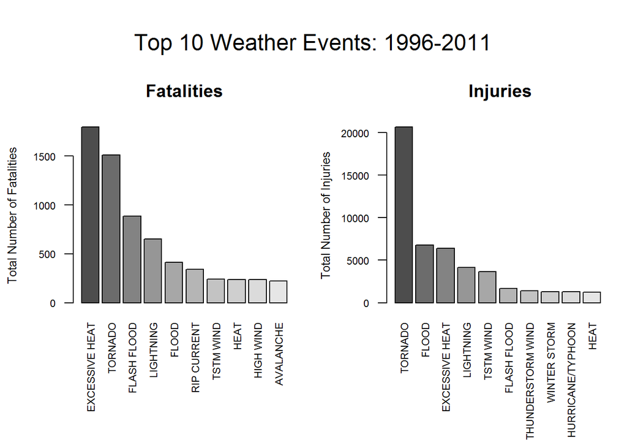

```r
par(mar=c(8, 4.1, 4.1, 1))
plot.new()


par(mfrow=c(1,2),oma = c(0, 0, 3, 0))

barplot(names.arg=fatalitiesSrt[,1],
        height=fatalitiesSrt[,2], ylab="Total Number of Fatalities", col= grey.colors(10, alpha=1),
        cex.names=0.7, cex.axis=0.7, cex.lab=0.8, las=2, main="Fatalities")

barplot(names.arg=injuriesSrt[,1],
        height=injuriesSrt[,2], ylab="Total Number of Injuries",col= grey.colors(10,alpha = 1),
        cex.names=0.7, cex.axis=0.7, cex.lab=0.8,las=2, main=" Injuries")
mtext("Top 10 Weather Events: 1996-2011", outer = TRUE, cex = 1.5)
```

*Readings* The above plots indicate that:

- The three top events, causing **Fatalities** are :
  - Excessive Heat
  - Tornado
  - Flash Flood
- The three top events, causing **Injuries** are :
  - Tornado
  - Flood
  - Excessive Heat

## III-B. Across the United States, which types of events have the greatest economic consequences?

- Aggregating event types by total Proper Damage

```r
propertyDamage <- aggregate(stormData1996$PROPERTY_DAMAGE ~ stormData1996$EVTYPE, FUN=sum)
colnames(propertyDamage)=c("Event","Property Damage")

#Finding the top 10 most harmful events causing Property Damage
pDamageSrt=
  propertyDamage [order(-propertyDamage$"Property Damage"),][1:10,]
```

- Aggregating event types by total Crop Damage

```r
cropDamage <- aggregate(stormData1996$CROP_DAMAGE ~ stormData1996$EVTYPE, FUN=sum)
dim(cropDamage)
```

```
## [1] 185   2
```

```r
colnames(cropDamage)=c("Event","Crop Damage")

#Finding the top 10 most harmful events causing Crop Damage
cDamageSrt=
  cropDamage [order(-cropDamage$"Crop Damage"),][1:10,]
```

### Plotting B (Economic Effects of Weather Events)

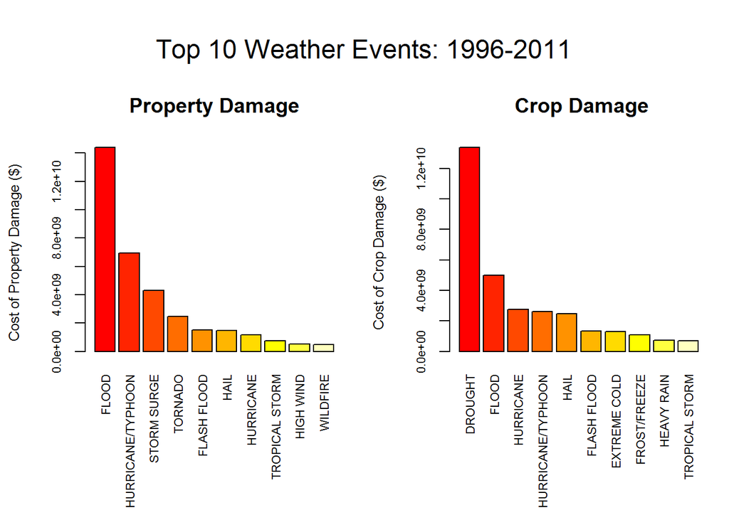

```r
par(mar=c(8, 4.1, 4.1, 1))
plot.new()

par(mfrow=c(1,2),oma = c(0, 0, 3, 0))

barplot(names.arg=pDamageSrt[,1],
        height=pDamageSrt[,2]/10, ylab="Cost of Property Damage ($) ", col= heat.colors(10,alpha = 1),
        cex.names=0.7,  cex.lab=0.8, las=2, main="Property Damage", yaxt="n")
axis(2,cex.axis=0.7)
barplot(names.arg=cDamageSrt[,1],
        height=cDamageSrt[,2], ylab="Cost of Crop Damage ($) ",col=heat.colors(10,alpha = 1),
        cex.names=0.7,  cex.lab=0.8,las=2, main=" Crop Damage", yaxt="n")
axis(2,cex.axis=0.7)
mtext("Top 10 Weather Events: 1996-2011", outer = TRUE, cex = 1.5)
```

*Readings* The above plots indicate that:

- The three top events, causing **Property damages** are :
  - Flood,
  - Hurricane/Typhoon
  - Storm Surge
- The three top events, causing **Crop damages** are :
  - Drought
  - Flood
  - Hurricane